# PISA Data Exploration

## by In-A Park

## Preliminary Wrangling

> This document explores a dataset containing how prepared student's compulsory education system for life beyond school

# Questions

I want to answer these questions

### Korea vs Finland

> 1. What type of math anxiety do they feel the most?
> 2. How did they attribute to failure in math test?
> 3. Which country get the high math score?
> 4. How did math anxiety affect math test?

### Math Anxiety

MA_1 : Worry that math will be difficult  
MA_2 : Get very Tense  
MA_3 : Get very Nervous  
MA_4 : Feel Helpless  
MA_5 : Worry about getting poor grades

### Attributions to Failure

AF_1 : I'm not good at math  
AF_2 : Teacher did not explain well  
AF_3 : Bad guesses  
AF_4 : Material Too Hard  
AF_5 : Teacher didn't get students Interested  
AF_6 : Unlucky

## Univariate Exploration

# How many student each of the country?

According to based on the dataset that we cleaned, we have 5033 Koran student and 8829 Finaland studnet.

# What type of Math Anxiety have appeared the most?

There are 5 types of Math Anxiety in this dataset.  
I draw the bar plot to see the most appeared Math Anxiety overall.  
Accordoing to this barplot, most of student worried about their poor math grade

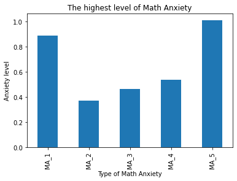

# What type of Attributions to failure have appeared the most?

There are 6typs of attributions to failure.  
I discoverd using barplot that most of student think the math material was so hard that they couldn't get good grade on math exam

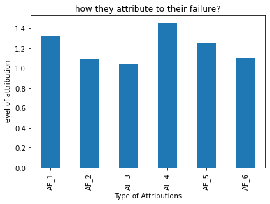

# How was their math score?

In this process I want to know the distribution of their math score.  
By using the histogram visulalization, the math score seems to be normally distributed

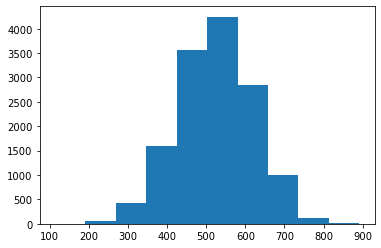

## Bivariate Exploration

## Is there any difference Math Anxiety between Korea and Finland?

In this process, I've done this in doing relative comparion between two country.  
According to this bar plot, overall the student living in Korea more feel anxiety about math than Finland

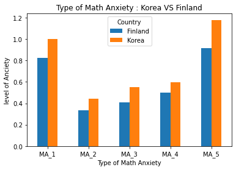

# Is there any difference Attributions to failure between Korea and Finland?

By using the bar plot visualization, we discovered both of country tend to attribute to failure to the material that they used.

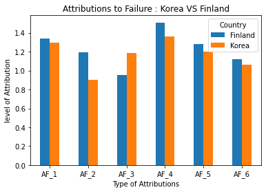

# Which country got a high math score?

I assumed that Finland student tend to have a good grade because they had less lower math anxiety than the korean student  
But that is not true. Based on this dataset, Korean student are a lot better at math than Finland student.

```
Country
Finland    507.525776
Korea      554.228404
Name: Score, dtype: float64
```

## Multivariate Exploration

## Do they have any relationship between variables?

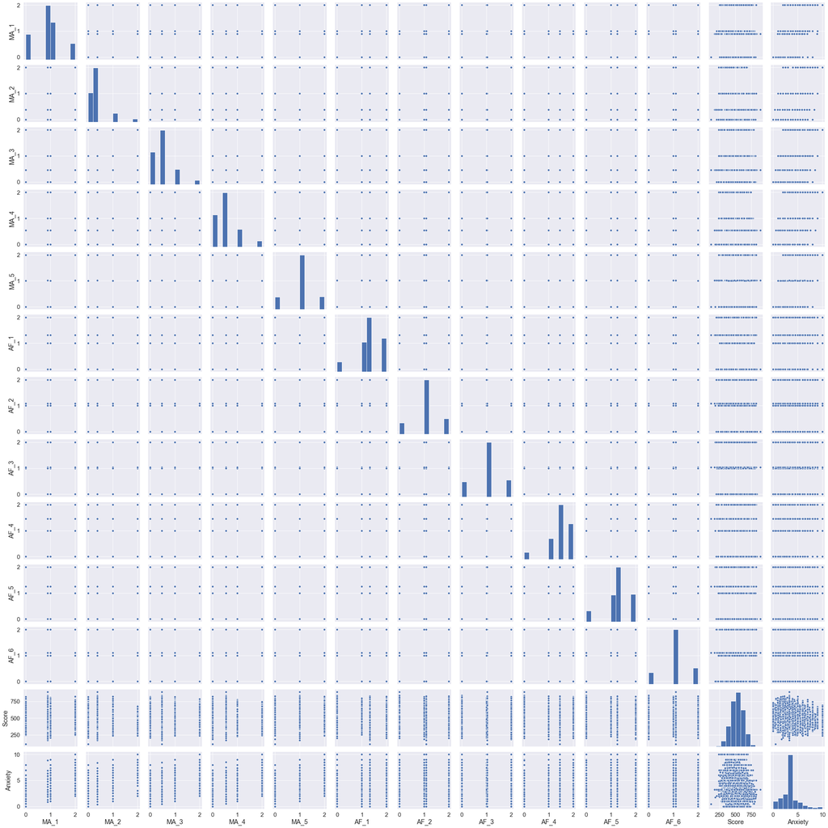

# Conclusion

Finally we can answer to these questions below.

### Korea vs Finland

> 1. What type of math anxiety do they feel the most?  
>    There are different types of anxiety that they have, but they feel worry about getting a poor grade in math test
> 2. How did they attribute to failure in math test?  
>    Both of country tend to attribute their failure to the education material that they had
> 3. Which country get the high math score?  
>    Korean student get the more high score than the Finland student
> 4. How did math anxiety affect math test?  
>    There is no clear relationship between variable, which I didn't expect